# Logistic Regression - Term Deposit Prediction

Vinayak

7/16/2019

# 1 Problem Statement

**OBJECTIVE**: Given the data from a bank(Bank_ds.txt) determine whether a subject subscribes to a term deposit or not.

The dataset has following attributes: - age (numeric)

- job : type of job (categorical: “admin.”,“unknown”,“unemployed”,“management”,“housemaid”,“entrepreneur”,“student”, “blue-collar”,“self-employed”,“retired”,“technician”,“services”)
- marital : marital status (categorical: “married”,“divorced”,“single”; note: “divorced” means divorced or widowed)
- education (categorical: “unknown”,“secondary”,“primary”,“tertiary”)
- default: has credit in default? (binary: “yes”,“no”)
- balance: average yearly balance, in euros (numeric)
- housing: has housing loan? (binary: “yes”,“no”)
- loan: has personal loan? (binary: “yes”,“no”)
- contact: contact communication type (categorical: “unknown”,“telephone”,“cellular”)
- day: last contact day of the month (numeric)
- month: last contact month of year (categorical: “jan”, “feb”, “mar”, …, “nov”, “dec”)
- duration: last contact duration, in seconds (numeric)
- campaign: number of contacts performed during this campaign and for this client (numeric, includes last contact)
- pdays: number of days that passed by after the client was last contacted from a previous campaign (numeric, -1 means client was not previously contacted)
- previous: number of contacts performed before this campaign and for this client (numeric)
- poutcome: outcome of the previous marketing campaign (categorical: “unknown”,“other”,“failure”,“success”)

Response Variable (desired target):

- y - has the client subscribed to a term deposit? (binary: “yes”,“no”)

# 2 Read/Observe the Data

Clear the workspace before starting a new analysis. Set the working directory to the folder in which your dataset resides. Read the data to a tibble. See the structure of the dataframe and go through a summary of descriptive stats pertaining to different features.

```r
rm(list = ls())
setwd("C:\\Users\\nayak\\Desktop\\INSOFE\\My_Scripts\\Logistic_Regression_Prediction_Term_Deposit_Subscription")
bank_ds = read.table("Bank_ds.txt", header = TRUE, sep = ";")
str(bank_ds)
```

```
## 'data.frame':    4521 obs. of  17 variables:
##  $ age      : int  30 33 35 30 59 35 36 39 41 43 ...
##  $ job      : Factor w/ 12 levels "admin.","blue-collar",..: 11 8 5 5 2 5 7 10 3 8 ...
##  $ marital  : Factor w/ 3 levels "divorced","married",..: 2 2 3 2 2 3 2 2 2 2 ...
##  $ education: Factor w/ 4 levels "primary","secondary",..: 1 2 3 3 2 3 3 2 3 1 ...
##  $ default  : Factor w/ 2 levels "no","yes": 1 1 1 1 1 1 1 1 1 1 ...
##  $ balance  : int  1787 4789 1350 1476 0 747 307 147 221 -88 ...
##  $ housing  : Factor w/ 2 levels "no","yes": 1 2 2 2 2 1 2 2 2 2 ...
##  $ loan     : Factor w/ 2 levels "no","yes": 1 2 1 2 1 1 1 1 1 2 ...
##  $ contact  : Factor w/ 3 levels "cellular","telephone",..: 1 1 1 3 3 1 1 1 3 1 ...
##  $ day      : int  19 11 16 3 5 23 14 6 14 17 ...
##  $ month    : Factor w/ 12 levels "apr","aug","dec",..: 11 9 1 7 9 4 9 9 9 1 ...
##  $ duration : int  79 220 185 199 226 141 341 151 57 313 ...
##  $ campaign : int  1 1 1 4 1 2 1 2 2 1 ...
##  $ pdays    : int  -1 339 330 -1 -1 176 330 -1 -1 147 ...
##  $ previous : int  0 4 1 0 0 3 2 0 0 2 ...
##  $ poutcome : Factor w/ 4 levels "failure","other",..: 4 1 1 4 4 1 2 4 4 1 ...
##  $ y        : Factor w/ 2 levels "no","yes": 1 1 1 1 1 1 1 1 1 1 ...
```

```r
head(bank_ds, 4)
```

```
##   age        job marital education default balance housing loan  contact
## 1  30 unemployed married   primary      no    1787      no   no cellular
## 2  33   services married secondary      no    4789     yes  yes cellular
## 3  35 management  single  tertiary      no    1350     yes   no cellular
## 4  30 management married  tertiary      no    1476     yes  yes  unknown
##   day month duration campaign pdays previous poutcome  y
## 1  19   oct       79        1    -1        0  unknown no
## 2  11   may      220        1   339        4  failure no
## 3  16   apr      185        1   330        1  failure no
## 4   3   jun      199        4    -1        0  unknown no
```

```r
tail(bank_ds, 4)
```

```
##      age           job marital education default balance housing loan
## 4518  57 self-employed married  tertiary     yes   -3313     yes  yes
## 4519  57    technician married secondary      no     295      no   no
## 4520  28   blue-collar married secondary      no    1137      no   no
## 4521  44  entrepreneur  single  tertiary      no    1136     yes  yes
##       contact day month duration campaign pdays previous poutcome  y
## 4518  unknown   9   may      153        1    -1        0  unknown no
## 4519 cellular  19   aug      151       11    -1        0  unknown no
## 4520 cellular   6   feb      129        4   211        3    other no
## 4521 cellular   3   apr      345        2   249        7    other no
```

# 3 Data Preprocessing

## 3.1 Missing Values

Check if the dataset given has any missing values. If yes, impute them using some imputation method eg. Target encoding or one-hot encoding.

```r
colSums(is.na(bank_ds))
```

```
##       age       job   marital education   default   balance   housing
##         0         0         0         0         0         0         0
##      loan   contact       day     month  duration  campaign     pdays
##         0         0         0         0         0         0         0
##  previous  poutcome         y
##         0         0         0
```

Since there aren’t any missing values, we’ll continue with the next step, else, ome way of encoding is essential because models do not understand anything but numbers. If any NA value is encountered, the model will run but it will produce unintuitive values.

## 3.2 Train/Test Split

Split the data into train and test data. The proportion of train:test should be 70:30.

### 3.2.1 Stratified Sampling.

When the data presented to us has a target variable which has disproportionately high number of observations for one class and consequently a small number of observations for another, it can lead to a problem called class imbalance.

**CLASS IMBALANCE:** When there are too many 1s or 0s and little 0s or 1s respectively in the target variable,a normal train test split may cause all the appearances of the minority class to get segregated into the test sample without any of them going into the train class. This will result into a problem since the model will encounter something other than what it has seen and it will collapse. To obviate this issue, we use stratified sampling.

**STRATIFIED SAMPLING:** A method of sampling in which train and test data contain roughly equal proportions of the two classes of target data. createDataPartition() function from the caret package can be used to implement this way of sampling.

```r
library(caret)
RNGversion("3.6.0")
set.seed(786)
train_rows = createDataPartition(bank_ds$y, p = 0.7, list = F)
# First argument - Target Variable
# Second Argument - Proportion of data to be captured
# Third Argument - By default, it returns a list. We cannot use a list to subset a tibble. Hence specify list = F. Then it will return a one dimensional matrix of numerics containing row numbers of the data frame.
train_data = bank_ds[train_rows,]
test_data = bank_ds[-train_rows,]
```

Showing the proportion of data in test and train in order to show how createDataPartition() works.

The dimensions of train data and the proportion of target variables in train data is as below:

```r
dim(train_data)
```

```
## [1] 3165   17
```

```r
table(train_data$y)
```

```
##
##   no  yes
## 2800  365
```

The dimensions of test data and the proportion of target variables in test data is as below:

```r
dim(test_data)
```

```
## [1] 1356   17
```

```r
table(test_data$y)
```

```
##
##   no  yes
## 1200  156
```

# 4 LR Model Building

Build a basic logistic regression model. Model the target as a function of all other variables in the dataset.  
Have a look at the summary of the model.

```r
LR = glm(y~., data = train_data, family = binomial)
# Since the target variable has only two values, mention the family as binomial.
summary(LR)
```

```
##
## Call:
## glm(formula = y ~ ., family = binomial, data = train_data)
##
## Deviance Residuals:
##     Min       1Q   Median       3Q      Max
## -4.1537  -0.3819  -0.2493  -0.1494   2.9904
##
## Coefficients:
##                      Estimate Std. Error z value Pr(>|z|)
## (Intercept)        -2.727e+00  7.218e-01  -3.778 0.000158 ***
## age                -4.000e-03  8.529e-03  -0.469 0.639071
## jobblue-collar     -3.375e-01  2.887e-01  -1.169 0.242428
## jobentrepreneur    -2.894e-01  4.667e-01  -0.620 0.535133
## jobhousemaid       -4.147e-01  4.966e-01  -0.835 0.403609
## jobmanagement      -5.628e-02  2.904e-01  -0.194 0.846361
## jobretired          5.241e-01  3.691e-01   1.420 0.155546
## jobself-employed   -3.574e-01  4.345e-01  -0.823 0.410753
## jobservices        -6.354e-02  3.196e-01  -0.199 0.842408
## jobstudent          1.324e-01  4.832e-01   0.274 0.784069
## jobtechnician      -3.095e-01  2.782e-01  -1.113 0.265917
## jobunemployed      -4.874e-01  4.948e-01  -0.985 0.324621
## jobunknown         -4.326e-01  9.026e-01  -0.479 0.631720
## maritalmarried     -4.781e-01  2.111e-01  -2.265 0.023530 *
## maritalsingle      -3.551e-01  2.447e-01  -1.451 0.146737
## educationsecondary  3.467e-01  2.498e-01   1.388 0.165089
## educationtertiary   6.837e-01  2.901e-01   2.356 0.018455 *
## educationunknown   -6.023e-01  4.665e-01  -1.291 0.196637
## defaultyes          2.382e-01  5.432e-01   0.439 0.660977
## balance            -1.059e-05  2.249e-05  -0.471 0.637852
## housingyes         -3.382e-01  1.659e-01  -2.038 0.041544 *
## loanyes            -7.626e-01  2.556e-01  -2.983 0.002850 **
## contacttelephone   -2.481e-01  2.975e-01  -0.834 0.404265
## contactunknown     -1.403e+00  2.727e-01  -5.143 2.71e-07 ***
## day                 1.081e-02  9.711e-03   1.113 0.265696
## monthaug           -3.671e-01  3.032e-01  -1.211 0.225978
## monthdec            1.462e-01  7.311e-01   0.200 0.841512
## monthfeb            2.237e-01  3.500e-01   0.639 0.522743
## monthjan           -9.038e-01  4.668e-01  -1.936 0.052862 .
## monthjul           -6.272e-01  3.023e-01  -2.075 0.037987 *
```

[output cut: 8 more lines]

```
## pdays              -1.225e-04  1.178e-03  -0.104 0.917159
## previous            6.734e-02  4.517e-02   1.491 0.136062
## poutcomeother       4.378e-01  3.257e-01   1.344 0.178847
## poutcomesuccess     2.220e+00  3.289e-01   6.748 1.50e-11 ***
## poutcomeunknown     1.409e-03  3.866e-01   0.004 0.997092
## ---
## Signif. codes:  0 '***' 0.001 '**' 0.01 '*' 0.05 '.' 0.1 ' ' 1
##
## (Dispersion parameter for binomial family taken to be 1)
##
##     Null deviance: 2263.0  on 3164  degrees of freedom
## Residual deviance: 1512.2  on 3122  degrees of freedom
## AIC: 1598.2
##
## Number of Fisher Scoring iterations: 6
```

**Understanding the summary** - First, you get the spread of residuals. Minimum, maxiumum and quartiles. - Then, you get the coefficients for the log of odds equation which were found by maximizing the log likelihood function.
$$i.e. ln(S) = \beta_0x_0 + \beta_1x_1 + ....... + \beta_nx_n$$

- Since the cost function here isn’t simple SSE, the statistical tests to check the significance of the model cannot be applied here. That’s why there ain’t any significane of model mentioned in the output.
- Null Deviance - If you were to draw an analogy between linear and logistic regression, null deviance would play the function of SST and accounts for the total deviation of observations around the mean.
- Residual Deviance - It is similar to SSR in linear regression.
- AIC - It is a measure of the information lost in the process of building the model. Hence it must be minimal in order to capture all info about the data. It is a comparitive measure. Hence it is useful when there are several models; it makes sense to pick the one with the least AIC.

# 5 ROC Curve

## 5.1 Prediction obj/ ROC plot

- The predict function on the glm object of family binomial gives a value of probability for each observation and not the final outcome i.e. 0 or 1.
- In order to get there, we need to select a threshold or cut-off value below which the observation can be assigned class 0 and above which it can be assigned class 1.
- In order to select the cut-off point, we can make use of an ROC curve.

Make predictions on the train data (i.e. get their probabilities using predict function and specifying *type = response* to the same) and subsequently build a prediction object.

**Note that the prediction function returns an object which has within it FP, TP, TN, FN, cutoffs, probability scores etc.**

```r
prob_train = predict(LR, type = 'response')
library(ROCR)
pred = prediction(prob_train, train_data$y)
```

After getting the prediction object, extract the performance measures from the prediction object using performance function from ROCR package.

```r
perf = performance(pred, measure = "tpr", x.measure = "fpr")
```

Plot the ROC curve using the extracted metrics from performance function

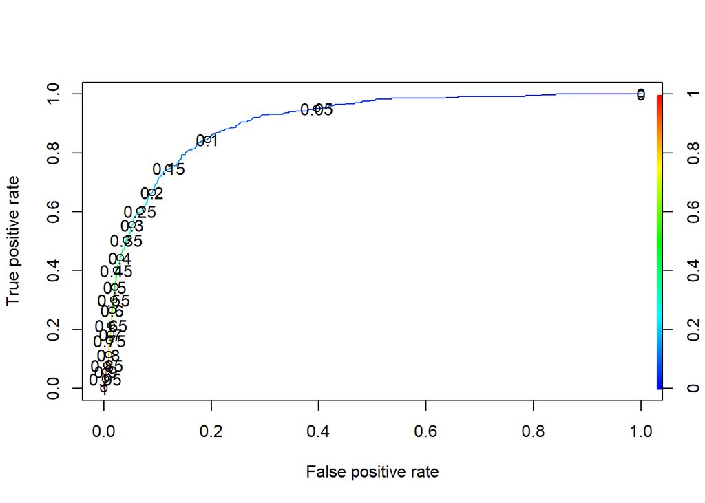

```r
plot(perf, colorize = T, print.cutoffs.at = seq(0,1,0.05))
```

Find out the AUC score of the ROC curve plotted above and comment on the same

```r
perf_auc = performance(pred, measure = "auc")
perf_auc
```

```
## An object of class "performance"
## Slot "x.name":
## [1] "None"
##
## Slot "y.name":
## [1] "Area under the ROC curve"
##
## Slot "alpha.name":
## [1] "none"
##
## Slot "x.values":
## list()
##
## Slot "y.values":
## [[1]]
## [1] 0.9036223
##
##
## Slot "alpha.values":
## list()
```

```r
perf_auc@y.values[[1]]
```

```
## [1] 0.9036223
```

## 5.2 Cut-off value selection

Based on the ROC curve, a decision needs to be made regarding the threshold probability beyond which a class can be categorized as class 1 or below which it could be classified as class 0.

- Note that **FPR = 1 - Specificity** This means that in order to maximize recall and specificity keeping in mind the tradeoff, you could select the threshold at the elbow point of ROC curve (by elbow, I mean the point after which TPR almost remains constant or the curve flattens out).

In this case, 0.1 looks like a good estimate to achieve a sensible trade-off between TPR and FPR.

```r
prob_test = predict(LR, test_data, type = 'response')
pred_test = ifelse(prob_test>0.1, "yes", "no")
```

# 6 Evaluation metrics

## 6.1 Confusion Matrix

Manually compute the confusion matrix and find out all the measures

```r
cm = table(test_data$y, pred_test)
print(cm)
```

```
##      pred_test
##        no yes
##   no  975 225
##   yes  31 125
```

### 6.1.1 Sensitivity

The proportion of correctly predicted positive classes wrt actual total positives.
$$Sensitivity(Recall) = \frac{TP}{TP+FN}$$

```r
cm[1,1]/ sum(cm[1,])
```

```
## [1] 0.8125
```

### 6.1.2 Specificity

The proportion of correctly predicted negative classes wrt total negatives
$$Specificity = \frac{TN}{FP+TN}$$

```r
cm[2,2] / sum(cm[2,])
```

```
## [1] 0.8012821
```

### 6.1.3 Accuracy

The proportion of correct observations wrt total observations.
$$Accuracy = \frac{TP+TN}{TP+TN+FP+FN}$$

```r
(cm[1,1] + cm[2,2])/sum(cm)
```

```
## [1] 0.8112094
```

### 6.1.4 Precision

The proportion of correct predictions made for positive class as compared to the total predictions made for the positive class

$$Precision = \frac{TP}{TP+FP}$$

```r
cm[1,1]/sum(cm[,1])
```

```
## [1] 0.9691849
```

### 6.1.5 F1 Score

In order to get decide whether we’ve achieved a good trade-off between precision and recall, we use this metric which is the harmonic mean of those two.

$$F_1 Score = \frac{2*Precision*Recall}{Precision + Recall}$$

```r
recall = cm[1,1]/ sum(cm[1,])
precision = cm[1,1]/sum(cm[,1])
2*precision*recall/(precision+recall)
```

```
## [1] 0.8839529
```

## 6.2 Automated Computation

The above metrics can be computed easily by using functions from the caret library. This is how you can achieve all the results shown above in one single step.

```r
library(caret)
library(e1071)
confusionMatrix(as.factor(pred_test), test_data$y, positive = "no")
```

```
## Confusion Matrix and Statistics
##
##           Reference
## Prediction  no yes
##        no  975  31
##        yes 225 125
##
##                Accuracy : 0.8112
##                  95% CI : (0.7893, 0.8317)
##     No Information Rate : 0.885
##     P-Value [Acc > NIR] : 1
##
##                   Kappa : 0.3983
##
##  Mcnemar's Test P-Value : <2e-16
##
##             Sensitivity : 0.8125
##             Specificity : 0.8013
##          Pos Pred Value : 0.9692
##          Neg Pred Value : 0.3571
##              Prevalence : 0.8850
##          Detection Rate : 0.7190
##    Detection Prevalence : 0.7419
##       Balanced Accuracy : 0.8069
##
##        'Positive' Class : no
##
```

# 7 Tackling Multicollinearity

- Overly large coefficients, huge error bars on the coefficient estimates and wrong signs on coefficients (after an intuitive judgement) can be indicators of multicollinearity.
- VIF can be used to check multicollinearity in these situations.
- R gives a *Generalized Variance Inflation Factor* which is a generalization to account for categorical variables.
- car package outputs $GVIF$ and $GVIF^\frac{1}{2*df}$ where df is the degrees of freedom of the categorical variable
- For *categorical predictors*, make sure **the square of** $GVIF^\frac{1}{2*df}$ **is less than 4** and for *numeric predictors*, the $GVIF$ itself should be **less than 4.**

```r
library(car)
LR_vif = vif(LR)
LR_vif
```

```
##               GVIF Df GVIF^(1/(2*Df))
## age       2.245909  1        1.498636
## job       5.451466 11        1.080135
## marital   1.432672  2        1.094049
## education 2.580690  3        1.171177
## default   1.047908  1        1.023674
## balance   1.076239  1        1.037419
## housing   1.470057  1        1.212459
## loan      1.071980  1        1.035365
## contact   2.075730  2        1.200308
## day       1.349839  1        1.161826
## month     5.148580 11        1.077332
## duration  1.152334  1        1.073468
## campaign  1.146205  1        1.070610
## pdays     3.891313  1        1.972641
## previous  1.923831  1        1.387022
## poutcome  5.844760  3        1.342130
```

# 8 Model Improvement - AIC

Use StepAIC in order to find out which variables can explain most of the given data while keeping the model simplistic.

```r
library(MASS)
LR_Step = stepAIC(LR, direction = "both")
```

```
## Start:  AIC=1598.16
## y ~ age + job + marital + education + default + balance + housing +
##     loan + contact + day + month + duration + campaign + pdays +
##     previous + poutcome
##
##             Df Deviance    AIC
## - job       11   1522.5 1586.5
## - pdays      1   1512.2 1596.2
## - default    1   1512.3 1596.3
## - age        1   1512.4 1596.4
## - balance    1   1512.4 1596.4
## - day        1   1513.4 1597.4
## <none>           1512.2 1598.2
## - previous   1   1514.3 1598.3
## - marital    2   1517.2 1599.2
## - housing    1   1516.3 1600.3
## - campaign   1   1518.2 1602.2
## - education  3   1524.6 1604.6
## - loan       1   1522.2 1606.2
## - contact    2   1540.5 1622.5
## - month     11   1577.4 1641.4
## - poutcome   3   1573.1 1653.1
## - duration   1   1933.3 2017.3
##
## Step:  AIC=1586.48
## y ~ age + marital + education + default + balance + housing +
##     loan + contact + day + month + duration + campaign + pdays +
##     previous + poutcome
##
##             Df Deviance    AIC
## - pdays      1   1522.5 1584.5
## - balance    1   1522.6 1584.6
## - default    1   1522.6 1584.6
## - age        1   1523.1 1585.1
## - day        1   1523.8 1585.8
## <none>           1522.5 1586.5
## - previous   1   1524.7 1586.7
## - marital    2   1528.6 1588.6
## - housing    1   1527.5 1589.5
## - campaign   1   1528.7 1590.7
```

[output cut: 108 more lines]

```
## + day        1   1523.3 1579.3
## + age        1   1524.1 1580.1
## + default    1   1524.5 1580.5
## + balance    1   1524.5 1580.5
## + pdays      1   1524.6 1580.6
## - marital    2   1531.0 1581.0
## - campaign   1   1530.2 1582.2
## - housing    1   1530.9 1582.9
## - loan       1   1535.2 1587.2
## + job       11   1514.2 1590.2
## - education  3   1543.0 1591.0
## - contact    2   1553.9 1603.9
## - month     11   1592.7 1624.7
## - poutcome   3   1586.7 1634.7
## - duration   1   1947.6 1999.6
```

```r
LR_AIC =  glm(y ~ marital + education + housing + loan + contact + month +
            duration + campaign + previous + poutcome, data = train_data, family =
            binomial)
```

# 9 Comparison Old vs New

**Summary of model built on reduced variables after AIC**

```r
summary(LR_AIC)
```

```
##
## Call:
## glm(formula = y ~ marital + education + housing + loan + contact +
##     month + duration + campaign + previous + poutcome, family = binomial,
##     data = train_data)
##
## Deviance Residuals:
##     Min       1Q   Median       3Q      Max
## -4.2332  -0.3872  -0.2538  -0.1535   3.0268
##
## Coefficients:
##                      Estimate Std. Error z value Pr(>|z|)
## (Intercept)        -2.8349637  0.4291886  -6.605 3.96e-11 ***
## maritalmarried     -0.5284430  0.2069190  -2.554  0.01065 *
## maritalsingle      -0.3865652  0.2249987  -1.718  0.08578 .
## educationsecondary  0.3603301  0.2284188   1.577  0.11468
## educationtertiary   0.7248504  0.2378593   3.047  0.00231 **
## educationunknown   -0.5634583  0.4483973  -1.257  0.20890
## housingyes         -0.3985598  0.1601602  -2.489  0.01283 *
## loanyes            -0.7694701  0.2530120  -3.041  0.00236 **
## contacttelephone   -0.1707232  0.2806964  -0.608  0.54305
## contactunknown     -1.3996761  0.2683927  -5.215 1.84e-07 ***
## monthaug           -0.4457565  0.2979940  -1.496  0.13469
## monthdec            0.2067358  0.7301840   0.283  0.77708
## monthfeb            0.0575409  0.3311236   0.174  0.86204
## monthjan           -0.7842894  0.4507960  -1.740  0.08190 .
## monthjul           -0.6002464  0.2993919  -2.005  0.04498 *
## monthjun            0.3914993  0.3522990   1.111  0.26645
## monthmar            1.9191675  0.4265461   4.499 6.82e-06 ***
## monthmay           -0.4653720  0.2766285  -1.682  0.09251 .
## monthnov           -0.7160031  0.3253212  -2.201  0.02774 *
## monthoct            1.0102656  0.4187188   2.413  0.01583 *
## monthsep            0.6510101  0.4929505   1.321  0.18662
## duration            0.0043698  0.0002473  17.672  < 2e-16 ***
## campaign           -0.0769193  0.0346955  -2.217  0.02662 *
## previous            0.0668083  0.0439503   1.520  0.12849
## poutcomeother       0.4332494  0.3214691   1.348  0.17775
## poutcomesuccess     2.1815949  0.3167965   6.886 5.72e-12 ***
## poutcomeunknown     0.0426652  0.2603140   0.164  0.86981
## ---
## Signif. codes:  0 '***' 0.001 '**' 0.01 '*' 0.05 '.' 0.1 ' ' 1
##
## (Dispersion parameter for binomial family taken to be 1)
##
##     Null deviance: 2263.0  on 3164  degrees of freedom
## Residual deviance: 1524.7  on 3138  degrees of freedom
## AIC: 1578.7
##
## Number of Fisher Scoring iterations: 6
```

**Summary of original model before AIC**

```r
summary(LR)
```

```
##
## Call:
## glm(formula = y ~ ., family = binomial, data = train_data)
##
## Deviance Residuals:
##     Min       1Q   Median       3Q      Max
## -4.1537  -0.3819  -0.2493  -0.1494   2.9904
##
## Coefficients:
##                      Estimate Std. Error z value Pr(>|z|)
## (Intercept)        -2.727e+00  7.218e-01  -3.778 0.000158 ***
## age                -4.000e-03  8.529e-03  -0.469 0.639071
## jobblue-collar     -3.375e-01  2.887e-01  -1.169 0.242428
## jobentrepreneur    -2.894e-01  4.667e-01  -0.620 0.535133
## jobhousemaid       -4.147e-01  4.966e-01  -0.835 0.403609
## jobmanagement      -5.628e-02  2.904e-01  -0.194 0.846361
## jobretired          5.241e-01  3.691e-01   1.420 0.155546
## jobself-employed   -3.574e-01  4.345e-01  -0.823 0.410753
## jobservices        -6.354e-02  3.196e-01  -0.199 0.842408
## jobstudent          1.324e-01  4.832e-01   0.274 0.784069
## jobtechnician      -3.095e-01  2.782e-01  -1.113 0.265917
## jobunemployed      -4.874e-01  4.948e-01  -0.985 0.324621
## jobunknown         -4.326e-01  9.026e-01  -0.479 0.631720
## maritalmarried     -4.781e-01  2.111e-01  -2.265 0.023530 *
## maritalsingle      -3.551e-01  2.447e-01  -1.451 0.146737
## educationsecondary  3.467e-01  2.498e-01   1.388 0.165089
## educationtertiary   6.837e-01  2.901e-01   2.356 0.018455 *
## educationunknown   -6.023e-01  4.665e-01  -1.291 0.196637
## defaultyes          2.382e-01  5.432e-01   0.439 0.660977
## balance            -1.059e-05  2.249e-05  -0.471 0.637852
## housingyes         -3.382e-01  1.659e-01  -2.038 0.041544 *
## loanyes            -7.626e-01  2.556e-01  -2.983 0.002850 **
## contacttelephone   -2.481e-01  2.975e-01  -0.834 0.404265
## contactunknown     -1.403e+00  2.727e-01  -5.143 2.71e-07 ***
## day                 1.081e-02  9.711e-03   1.113 0.265696
## monthaug           -3.671e-01  3.032e-01  -1.211 0.225978
## monthdec            1.462e-01  7.311e-01   0.200 0.841512
## monthfeb            2.237e-01  3.500e-01   0.639 0.522743
## monthjan           -9.038e-01  4.668e-01  -1.936 0.052862 .
## monthjul           -6.272e-01  3.023e-01  -2.075 0.037987 *
```

[output cut: 8 more lines]

```
## pdays              -1.225e-04  1.178e-03  -0.104 0.917159
## previous            6.734e-02  4.517e-02   1.491 0.136062
## poutcomeother       4.378e-01  3.257e-01   1.344 0.178847
## poutcomesuccess     2.220e+00  3.289e-01   6.748 1.50e-11 ***
## poutcomeunknown     1.409e-03  3.866e-01   0.004 0.997092
## ---
## Signif. codes:  0 '***' 0.001 '**' 0.01 '*' 0.05 '.' 0.1 ' ' 1
##
## (Dispersion parameter for binomial family taken to be 1)
##
##     Null deviance: 2263.0  on 3164  degrees of freedom
## Residual deviance: 1512.2  on 3122  degrees of freedom
## AIC: 1598.2
##
## Number of Fisher Scoring iterations: 6
```